# biol792ia3

morgan hrivnak

2024-11-14

```r
library(rethinking)
library(tidyverse)
library(dplyr)
library(tibble)
library(raster)
library(here)
df <- readRDS(here("alldata_wrangled.rds"))

#assign non-numerical for percent_lessorequal
df$percent_lessorequal <- as.numeric(df$percent_lessorequal)
#filter out NA values
df_clean <- df %>%
  filter(!is.na(percent_lessorequal))
#select only the necessary collumns
df_cleaner <- df_clean %>%
  dplyr::select(percent_lessorequal, size, site, percent)

#select CARI and MCDI site
selected_sites <- df_cleaner %>%
  filter(site %in% c("MCDI", "CARI"))
print(selected_sites)
```

```
## # A tibble: 24 × 4
##    percent_lessorequal  size site  percent
##                  <dbl> <dbl> <chr>   <dbl>
##  1                 6.8   6.8 MCDI        5
##  2                18.1  18.1 MCDI       16
##  3                42.3  42.3 MCDI       50
##  4                29.9  29.9 MCDI       50
##  5               163.  163.  MCDI       84
##  6                13    13   MCDI        5
##  7                23.5  23.5 MCDI       16
##  8                53.3  53.3 MCDI       50
##  9                 4     4   MCDI       16
## 10                28.6  28.6 MCDI       50
## # ℹ 14 more rows
```

```r
# #standardize selected sites
# sites_standard <- selected_sites %>%
#   mutate(across(where(is.numeric), scale))
# head(sites_standard)


#make variable into index
selected_sites$cid <-ifelse(selected_sites$site == "MCDI", 1, 2)

#main meat but make it gamma
# mod1gamma <- ulam(
#   alist(
#     size ~ dgamma2(mu, scale),
#     log(mu) <- a + bP * percent ,
#     a ~ dnorm(0, 1) ,
#     bP ~ dnorm(0, 1) ,
#     scale ~ dexp(10)
#   ),
#   data= selected_sites,
#   iter= 2000,
#   chains = 4,
#   warmup =1000)
#
# precis(mod1gamma)
#
# mod2gamma <- ulam(
#   alist(
#     size ~ dgamma2(mu, scale),
#     log(mu) <- a[cid] + b[cid] * percent ,
#     a[cid] ~ dnorm(0,1) ,
#     b[cid] ~ dnorm(0,1) ,
#     scale ~ dexp (10)
#   ),
#   data= selected_sites,
#   iter= 2000,
#   chains = 4,
#   warmup =1000)
#
# precis(mod2gamma, depth = 2)
```

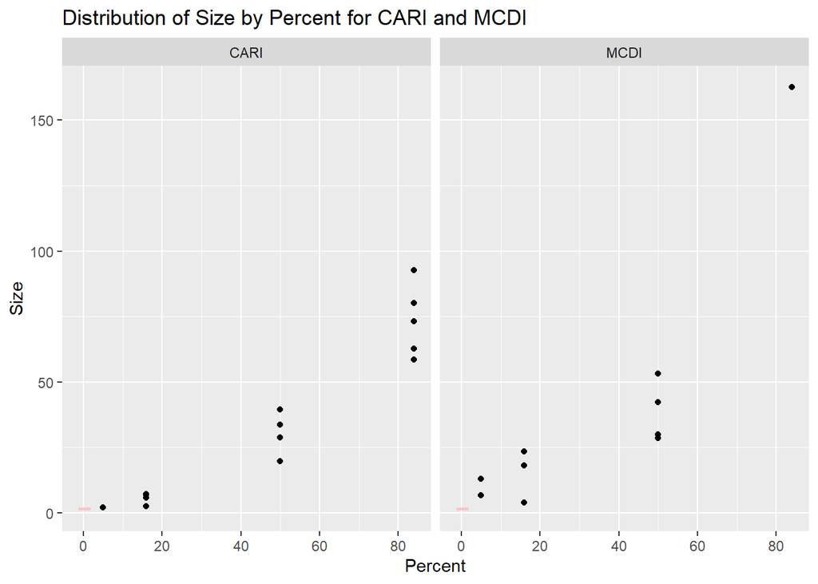

```r
posts = extract.samples(mod3gamma)

posts_table = tibble(a1 = posts$a[,1],
                     a2 = posts$a[,2],
                     b1 = posts$b[,1],
                     b2 = posts$b[,2]) %>%
  mutate(iter = 1:nrow(.))

post_preds = posts_table %>%
  filter(iter <= 100) %>%
  expand_grid(percent = seq(-1.2, 2)) %>%
  mutate(size = a2 + b2*percent)

ggplot(data = selected_sites %>% filter(site %in% c("CARI", "MCDI")), aes(x = percent, y = size)) +
  geom_point() +
  geom_line(data = post_preds, aes(group = iter), color="pink", alpha = 0.2,) +
  facet_wrap(~site) +  # Create separate panels for each site
  labs(title = "Distribution of Size by Percent for CARI and MCDI",
       x = "Percent",
       y = "Size")  # Add titles and labels
```

MCDI is a NEON site in Flint Hills region of Kansas south of Manhattan, KS. CARI is a NEON site in central Alaska at the CPCRW northeast of Fairbanks, Alaska. This examines the interaction of the size of substrate present in total sample percent between sites MCDI and CARI. The data is not standardized and was put into a gamma distribution. The data falls into a gamma distribution because the occurrences are independent and the average occurrences remain the same from unit to unit. Not only that but the possible occurrences are not limited to a fixed number.

This relationship makes biological sense as it should be positive. It should be a positive relationship as you go along the x-axis it encompasses more of the samples for that given site. The rate in which it increases tells us that MCDI has more larger substrate (cobbles) than CARI. CARI has more finer substrate than MCDI. Geologically speaking this also makes sense as CARI is located in Alaska while MCDI is located in Kansas. These streams have very different geological process affecting them as well as human activity, MAT, and MAP. CARI. We would expect this kind of substrate at CARI to have glacial till and for soil to be affected by permafrost thaws. This is hard to examine looking at NEON images of this site in particular due to the water level. At MCDI you can see that generally where they survey the stream it has high banks on one side and what appears to be gravel or small cobbles on the other bank.